# Bio-Sparte Zusammenfassung

# Bio-Sparte

## 0 Connection

### 0.1 DbConnection

### 0.2 Einbettung der R-Objekte

```r
items_per_order <- readRDS('./data/products_by_order.rds')
orders <- readRDS('./data/orders.rds')
orders_per_hour_per_day <- readRDS('./data/orders_per_hour_per_day.rds')
products_per_hour_per_day <- readRDS('./data/products_per_hour_per_day.rds')
products_by_order <- readRDS('./data/products_by_order.rds')
departments <- readRDS('./data/departments.rds')
products <- readRDS('./data/products.rds')
```

| ################################################################################################### |
| --- |

## Annahme 1 : Um heruaszufinden was für ein Laden, im Bezug auf Bio, der untersuchte Supermarkt ist haben wir zuerst mal untersucht wie es mit den Bio-Produkten aussieht

### Frage 1.1: Was ist die aktuelle Situation des Ladens zu Bio-Produkten im Laden?

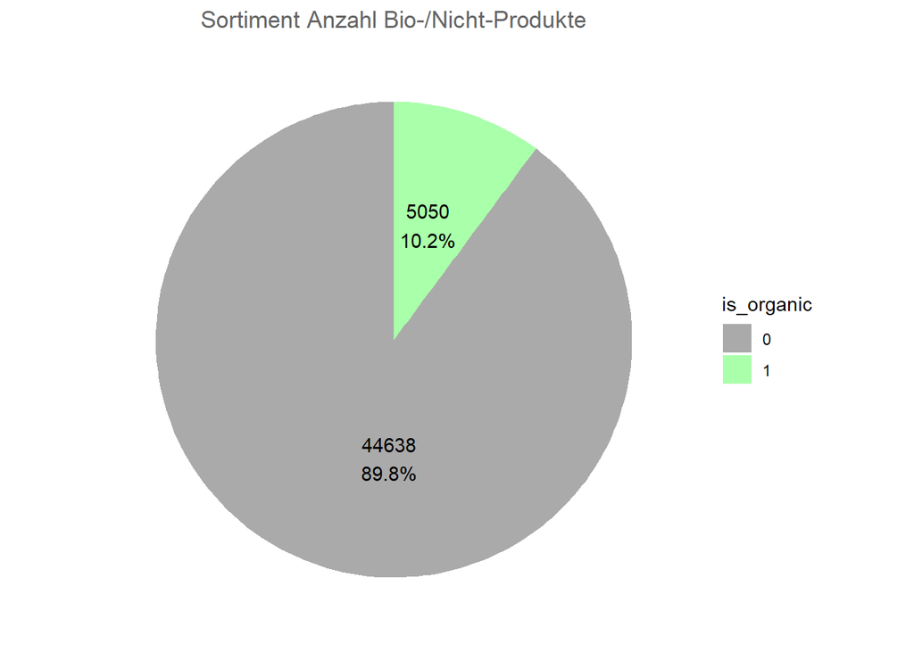

### Antwort 1.1 : Der Anteil an Bio-Produkten im Sortiment ist 10.16%

### Frage 1.2 : Wie viele Bio-Produkte werden im Vergleich zu nicht- Bio Produkten eingekauft?

| is_organic | n |
| --- | --- |
| 0 | 23161360 |
| 1 | 10657749 |

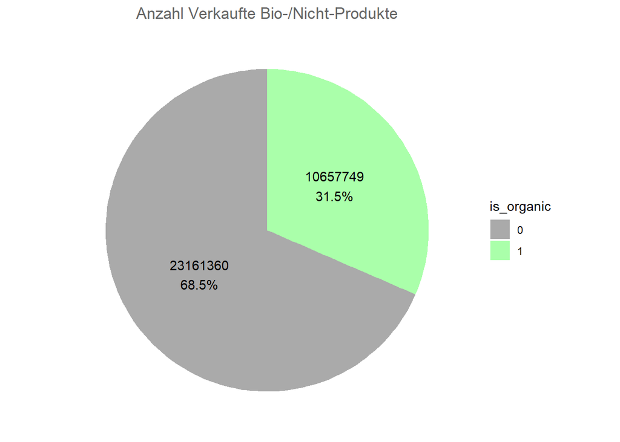

### Antwort 1.2 : Der Anteil an eingekauften Bio-Produkten beträgt 31.51 %

## Auswertung 1 : Der untersuchte Supermarkt hat einen Bio-Anteil an eingekauften Produkten von 31% was ein grosser Unterschied zu den c.a 10% Bio-Produkten im Angebot ist. Wir stellen fest, dass es hier ein Verbesserung gemacht werden kann. Wir wollen die Nachfrage erhöhen indem wir das Angebot erhöhen. Doch wo genau sollen mehr Bio-Produkte eingesetzt werden ?

```r
product_sold_org_byDepartment<- inner_join(products, departments, "department") %>%
  group_by(department) %>%
    count(is_organic) %>%
  group_by(department) %>%
  arrange(is_organic)  %>%
  mutate(n = as.integer(n)) %>%
  mutate(nn = lag(n)) %>%
  mutate(sold_org = n, sold_notorg = nn) %>%
  mutate(total_sold_byDepartment = sum(sold_org)) %>%
  select(-c(n,nn, is_organic)) %>%
  filter(!is.na(sold_notorg)) %>%
  mutate(sold_org_byPercent = round(100*sold_org/total_sold_byDepartment, digits = 2)) %>%
  arrange(desc(sold_org_byPercent))

product_sold_org_byDepartment
```

| department | sold_org | sold_notorg | total_sold_byDepartment | sold_org_byPercent |
| --- | --- | --- | --- | --- |
| bulk | 22 | 16 | 38 | 57.89 |
| produce | 473 | 1211 | 1684 | 28.09 |
| babies | 260 | 821 | 1081 | 24.05 |
| dry goods pasta | 300 | 1558 | 1858 | 16.15 |
| canned goods | 320 | 1772 | 2092 | 15.30 |
| beverages | 624 | 3741 | 4365 | 14.30 |
| pantry | 753 | 4618 | 5371 | 14.02 |
| missing | 175 | 1083 | 1258 | 13.91 |
| breakfast | 155 | 960 | 1115 | 13.90 |
| dairy eggs | 437 | 3012 | 3449 | 12.67 |

[output cut: 11 more lines]

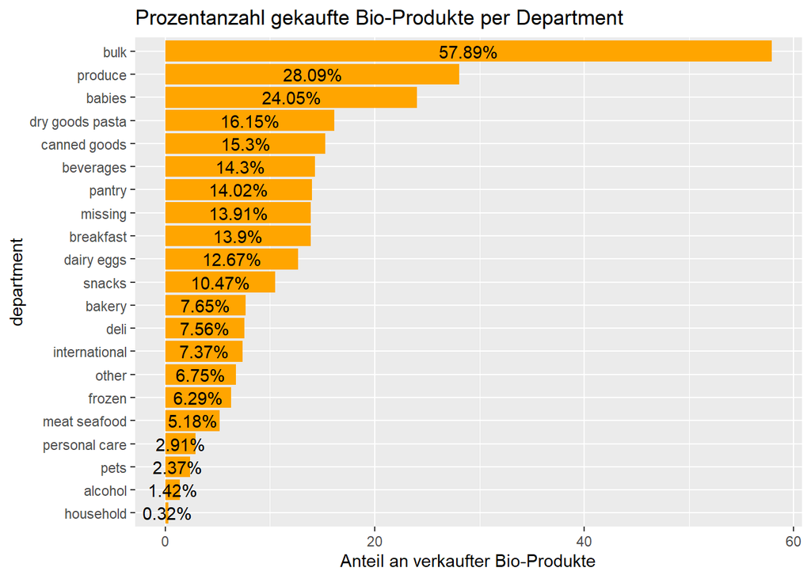

```r
ggplot(product_sold_org_byDepartment, aes(x = reorder(department, sold_org_byPercent), y = sold_org_byPercent)) +
  labs(x = "department", y = "Anteil an verkaufter Bio-Produkte",  title = "Prozentanzahl gekaufte Bio-Produkte per Department") +
  geom_col(fill="orange") +
  geom_text(aes(label = paste0(sold_org_byPercent, "%")), position = position_stack(vjust = 0.5)) +
  coord_flip()
```

## Frage 1.4 : Welches sind die top 5 departments, in welchen das Verhältniss an gekaufen Bio Produkten zu vohandenen Bio-Produkten am grössten ist.

```r
ratio_products_org_notorg_per_departments <- inner_join(departments, products) %>%
  group_by(department, is_organic) %>%
  summarise(count = n()) %>%
  arrange(department) %>%
  collect()%>%
  spread(key = is_organic, value = count) %>%
  rename(notorganic = `0`, is_organic = `1`) %>%
  mutate(all_products = notorganic + is_organic, freqProd = is_organic/all_products *100) %>%
  arrange(desc(freqProd))
ratio_orders_org_notorg_per_departments <-  inner_join(orders, products) %>%
  inner_join(departments) %>%
  group_by(department, is_organic) %>%
  summarise(count = n()) %>%
  arrange(department) %>%
  collect()%>%
  spread(key = is_organic, value = count) %>%
  rename(notorganic = `0`, is_organic = `1`) %>%
  mutate(all_products = notorganic + is_organic, freqBought = is_organic/all_products *100) %>%
  arrange(desc(freqBought))
improvement_departments_top5 <- ratio_orders_org_notorg_per_departments %>%
  select(department,freqBought) %>%
  left_join(ratio_products_org_notorg_per_departments) %>%
  select(department,freqBought,freqProd) %>%
  mutate(diff = freqBought-freqProd) %>%
  arrange(desc(diff)) %>%
  head(5)
ratio_products_org_notorg_per_departments
```

| department | notorganic | is_organic | all_products | freqProd |
| --- | --- | --- | --- | --- |
| bulk | 16 | 22 | 38 | 57.8947368 |
| produce | 1211 | 473 | 1684 | 28.0878860 |
| babies | 821 | 260 | 1081 | 24.0518039 |
| dry goods pasta | 1558 | 300 | 1858 | 16.1463940 |
| canned goods | 1772 | 320 | 2092 | 15.2963671 |
| beverages | 3741 | 624 | 4365 | 14.2955326 |
| pantry | 4618 | 753 | 5371 | 14.0197356 |
| missing | 1083 | 175 | 1258 | 13.9109698 |
| breakfast | 960 | 155 | 1115 | 13.9013453 |
| dairy eggs | 3012 | 437 | 3449 | 12.6703392 |

[output cut: 11 more lines]

```r
ratio_orders_org_notorg_per_departments
```

| department | notorganic | is_organic | all_products | freqBought |
| --- | --- | --- | --- | --- |
| produce | 4564754 | 5323624 | 9888378 | 53.83718139 |
| canned goods | 577989 | 536868 | 1114857 | 48.15577244 |
| bulk | 18878 | 17054 | 35932 | 47.46187243 |
| babies | 249664 | 189079 | 438743 | 43.09561634 |
| missing | 45162 | 32234 | 77396 | 41.64814719 |
| dairy eggs | 3865924 | 1765143 | 5631067 | 31.34651035 |
| dry goods pasta | 657083 | 248257 | 905340 | 27.42141074 |
| pantry | 1514109 | 442710 | 1956819 | 22.62396267 |
| breakfast | 587281 | 151788 | 739069 | 20.53773058 |
| meat seafood | 593078 | 146160 | 739238 | 19.77171087 |

[output cut: 11 more lines]

```r
improvement_departments_top5
```

| department | freqBought | freqProd | diff |
| --- | --- | --- | --- |
| canned goods | 48.15577 | 15.29637 | 32.85941 |
| missing | 41.64815 | 13.91097 | 27.73718 |
| produce | 53.83718 | 28.08789 | 25.74930 |
| babies | 43.09562 | 24.05180 | 19.04381 |
| dairy eggs | 31.34651 | 12.67034 | 18.67617 |

### Antwort 1.4 : Es sind die Departments : canned goods, missing, produce, babies, dairy eggs

### Frage 1.5 : Was sind die meist gekauften Bio-Produkte in diesen departments?

```r
#1 : canned goods- departement :15

most_bought_canned_goods <- inner_join(orders, products, "product_id") %>%
  filter(department_id == 15) %>%
  group_by(is_organic)%>%
  select(c("is_organic", "product_name"))%>%
  count(n = product_name)%>%
  arrange(desc(nn))

top10orgProdInCannedGoods <-filter(most_bought_canned_goods, is_organic == TRUE) %>%
  head(10)

#2 : missing- departement :21
most_bought_missing <- inner_join(orders, products, "product_id") %>%
  filter(department_id == 21) %>%
  group_by(is_organic)%>%
  select(c("is_organic", "product_name"))%>%
  count(n = product_name)%>%
  arrange(desc(nn))

top10orgProdInMissing <- filter(most_bought_missing, is_organic == TRUE) %>%
  head(10)

#3 : produce- departement :4
most_bought_produce <- inner_join(orders, products, "product_id") %>%
  filter(department_id == 4) %>%
  group_by(is_organic)%>%
  select(c("is_organic", "product_name"))%>%
  count(n = product_name)%>%
  arrange(desc(nn))

top10orgProdInProduce <- filter(most_bought_produce, is_organic == TRUE) %>%
  head(10)

#4 : babies- departement :18
most_bought_babies <- inner_join(orders, products, "product_id") %>%
  filter(department_id == 18) %>%
  group_by(is_organic)%>%
  select(c("is_organic", "product_name"))%>%
  count(n = product_name)%>%
  arrange(desc(nn))

top10orgProdInBabies <- filter(most_bought_babies, is_organic == TRUE) %>%
  head(10)


#5 : dairy eggs- departement :16
most_bought_dairy_eggs <- inner_join(orders, products, "product_id") %>%
  filter(department_id == 16) %>%
  group_by(is_organic)%>%
  select(c("is_organic", "product_name"))%>%
  count(n = product_name)%>%
  arrange(desc(nn))

most_bought_dairy_eggs
```

| is_organic | n | nn |
| --- | --- | --- |
| 1 | Organic Whole Milk | 142813 |
| 1 | Organic Half & Half | 79006 |
| 0 | Half & Half | 71641 |
| 1 | Organic Whole String Cheese | 61669 |
| 1 | Organic Unsweetened Almond Milk | 60071 |
| 0 | Unsweetened Almondmilk | 51738 |
| 1 | Organic Reduced Fat 2% Milk | 49374 |
| 0 | Grated Parmesan | 46932 |
| 0 | Large Alfresco Eggs | 42274 |
| 1 | Organic Grade A Free Range Large Brown Eggs | 41812 |

[output cut: 3439 more lines]

```r
top10orgProdInDairyEggs <- filter(most_bought_dairy_eggs, is_organic == TRUE) %>%
  head(10)

top10orgProdInCannedGoods
```

| is_organic | n | nn |
| --- | --- | --- |
| 1 | Organic Black Beans | 39577 |
| 1 | Organic Garbanzo Beans | 31196 |
| 1 | Organic Diced Tomatoes | 22834 |
| 1 | Organic Tomato Paste | 18336 |
| 1 | Organic Low Sodium Chicken Broth | 18252 |
| 1 | Organic AppleApple | 16780 |
| 1 | Organic Tomato Sauce | 14181 |
| 1 | Organic Free Range Chicken Broth | 13376 |
| 1 | Organic Whole Kernel Sweet Corn No Salt Added | 13330 |
| 1 | Organic Vegetable Broth | 12126 |

```r
top10orgProdInMissing
```

| is_organic | n | nn |
| --- | --- | --- |
| 1 | Organic Riced Cauliflower | 9189 |
| 1 | Organic Celery Bunch | 1845 |
| 1 | Organic Mango Yogurt | 1804 |
| 1 | Organic Whole Milk Washington Black Cherry Yogurt | 1506 |
| 1 | Organic Nondairy Strawberry Cashew Yogurt | 987 |
| 1 | Organic Plain Unsweetened Nondairy Cashew Yogurt | 956 |
| 1 | Organic Ground Chicken | 877 |
| 1 | Organic Cashew Nondairy Vanilla Yogurt | 859 |
| 1 | Organic Chocolate Chip Cookie Dough | 775 |
| 1 | Organic Uncured Beef Hot Dog | 700 |

```r
top10orgProdInProduce
```

| is_organic | n | nn |
| --- | --- | --- |
| 1 | Bag of Organic Bananas | 394930 |
| 1 | Organic Strawberries | 275577 |
| 1 | Organic Baby Spinach | 251705 |
| 1 | Organic Hass Avocado | 220877 |
| 1 | Organic Avocado | 184224 |
| 1 | Organic Raspberries | 142603 |
| 1 | Organic Yellow Onion | 117716 |
| 1 | Organic Garlic | 113936 |
| 1 | Organic Zucchini | 109412 |
| 1 | Organic Blueberries | 105026 |

```r
top10orgProdInBabies
```

| is_organic | n | nn |
| --- | --- | --- |
| 1 | Organic Mixed Berry Yogurt & Fruit Snack | 5743 |
| 1 | Stage 1 Apples Sweet Potatoes Pumpkin & Blueberries Organic Pureed Baby Food | 5727 |
| 1 | Organic Pears, Peas and Broccoli Puree Stage 1 | 5148 |
| 1 | Organic Strawberry Yogurt & Fruit Snack | 4710 |
| 1 | Organic Whole Grain Oatmeal Cereal Baby Food | 4504 |
| 1 | Organic Stage 4 Spinach Mango & Pear Baby Food | 4131 |
| 1 | Organic Stage 4 Green Bean Pear & Pea Baby Food | 3865 |
| 1 | Organic Strawberry Banana Fruit Yogurt Smoothie | 3580 |
| 1 | Sweeet Potato, Apple, Carrot & Cinnamon Organic Superfoods | 3539 |
| 1 | Organic Stage 2 Peaches & Bananas Baby Food | 3462 |

```r
top10orgProdInDairyEggs
```

| is_organic | n | nn |
| --- | --- | --- |
| 1 | Organic Whole Milk | 142813 |
| 1 | Organic Half & Half | 79006 |
| 1 | Organic Whole String Cheese | 61669 |
| 1 | Organic Unsweetened Almond Milk | 60071 |
| 1 | Organic Reduced Fat 2% Milk | 49374 |
| 1 | Organic Grade A Free Range Large Brown Eggs | 41812 |
| 1 | Organic Reduced Fat Milk | 36869 |
| 1 | Organic Sticks Low Moisture Part Skim Mozzarella String Cheese | 35551 |
| 1 | Organic Large Brown Grade AA Cage Free Eggs | 33242 |
| 1 | Organic Milk | 28850 |

### Antwort 1.5 : Es sind

| is_organic | n | nn |
| --- | --- | --- |
| 1 | Organic Black Beans | 39577 |
| 1 | Organic Garbanzo Beans | 31196 |
| 1 | Organic Diced Tomatoes | 22834 |
| 1 | Organic Tomato Paste | 18336 |
| 1 | Organic Low Sodium Chicken Broth | 18252 |
| 1 | Organic AppleApple | 16780 |
| 1 | Organic Tomato Sauce | 14181 |
| 1 | Organic Free Range Chicken Broth | 13376 |
| 1 | Organic Whole Kernel Sweet Corn No Salt Added | 13330 |
| 1 | Organic Vegetable Broth | 12126 |

| is_organic | n | nn |
| --- | --- | --- |
| 1 | Organic Riced Cauliflower | 9189 |
| 1 | Organic Celery Bunch | 1845 |
| 1 | Organic Mango Yogurt | 1804 |
| 1 | Organic Whole Milk Washington Black Cherry Yogurt | 1506 |
| 1 | Organic Nondairy Strawberry Cashew Yogurt | 987 |
| 1 | Organic Plain Unsweetened Nondairy Cashew Yogurt | 956 |
| 1 | Organic Ground Chicken | 877 |
| 1 | Organic Cashew Nondairy Vanilla Yogurt | 859 |
| 1 | Organic Chocolate Chip Cookie Dough | 775 |
| 1 | Organic Uncured Beef Hot Dog | 700 |

| is_organic | n | nn |
| --- | --- | --- |
| 1 | Bag of Organic Bananas | 394930 |
| 1 | Organic Strawberries | 275577 |
| 1 | Organic Baby Spinach | 251705 |
| 1 | Organic Hass Avocado | 220877 |
| 1 | Organic Avocado | 184224 |
| 1 | Organic Raspberries | 142603 |
| 1 | Organic Yellow Onion | 117716 |
| 1 | Organic Garlic | 113936 |
| 1 | Organic Zucchini | 109412 |
| 1 | Organic Blueberries | 105026 |

| is_organic | n | nn |
| --- | --- | --- |
| 1 | Organic Mixed Berry Yogurt & Fruit Snack | 5743 |
| 1 | Stage 1 Apples Sweet Potatoes Pumpkin & Blueberries Organic Pureed Baby Food | 5727 |
| 1 | Organic Pears, Peas and Broccoli Puree Stage 1 | 5148 |
| 1 | Organic Strawberry Yogurt & Fruit Snack | 4710 |
| 1 | Organic Whole Grain Oatmeal Cereal Baby Food | 4504 |
| 1 | Organic Stage 4 Spinach Mango & Pear Baby Food | 4131 |
| 1 | Organic Stage 4 Green Bean Pear & Pea Baby Food | 3865 |
| 1 | Organic Strawberry Banana Fruit Yogurt Smoothie | 3580 |
| 1 | Sweeet Potato, Apple, Carrot & Cinnamon Organic Superfoods | 3539 |
| 1 | Organic Stage 2 Peaches & Bananas Baby Food | 3462 |

| is_organic | n | nn |
| --- | --- | --- |
| 1 | Organic Whole Milk | 142813 |
| 1 | Organic Half & Half | 79006 |
| 1 | Organic Whole String Cheese | 61669 |
| 1 | Organic Unsweetened Almond Milk | 60071 |
| 1 | Organic Reduced Fat 2% Milk | 49374 |
| 1 | Organic Grade A Free Range Large Brown Eggs | 41812 |
| 1 | Organic Reduced Fat Milk | 36869 |
| 1 | Organic Sticks Low Moisture Part Skim Mozzarella String Cheese | 35551 |
| 1 | Organic Large Brown Grade AA Cage Free Eggs | 33242 |
| 1 | Organic Milk | 28850 |

## Auswertung 1.2: Es gibt eine eindeutige Diskrepanz der gekauften Bio-Produkte und der Bio-Produkten im Sortiment. Diese Diskrepanz unterscheidet sich von Department zu Department. Um eine klare Aussage zu treffen, wo man diese Diskrepanz am besten angeht haben wir uns für die top 5 Departments entschieden, wo sie am grössten ist.

| ################################################################################################### |
| --- |

## Annahme 2 : Es ist wichtig die beliebten Bio-Produkte zu bewerben, weil die allgemein viel gekauft werde und auch sehr beliebt sind. Wir wollen kain Cross-Selling betreiben, indem wir die Bio-Produkte irgendwie neben andere häuffig gekaufte stellen, sondern Bio-Produkte sollten in der Regel genau nebenden equivalenten Nicht-Bio-Produten stehen.

### Frage 2.1 : Was sind die meist verkauften Produkte? Und wie viele davon sind Bio?

[output not shown]

[output cut: 9990 more lines]

| is_organic | product_name | n |
| --- | --- | --- |
| 0 | Banana | 491291 |
| 1 | Bag of Organic Bananas | 394930 |
| 1 | Organic Strawberries | 275577 |
| 1 | Organic Baby Spinach | 251705 |
| 1 | Organic Hass Avocado | 220877 |
| 1 | Organic Avocado | 184224 |
| 0 | Large Lemon | 160792 |
| 0 | Strawberries | 149445 |
| 0 | Limes | 146660 |
| 1 | Organic Whole Milk | 142813 |

[output cut: 20 more lines]

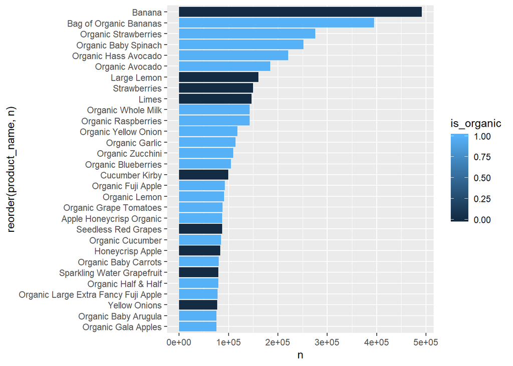

### Antwort 2.1: Es sind : Banana, Bag of Organic Bananas, Organic Strawberries, Organic Baby Spinach, Organic Hass Avocado, Organic Avocado

### Frage 2.2 : Was sind die meist verkauften Bio-Produkte?

```r
# Determine most bought organic products

most_bought_org <- full_join(products, orders, "product_id") %>%
    select(c(product_id, product_name, orders_id, is_organic)) %>%
  mutate(is_organic = as.integer(is_organic)) %>%
  filter(is_organic == 1) %>%
    count(product_name) %>%
  mutate(n = as.integer(n))  %>%
    arrange(-n) %>%
    head(30)

most_bought_org
```

| product_name | n |
| --- | --- |
| Bag of Organic Bananas | 394930 |
| Organic Strawberries | 275577 |
| Organic Baby Spinach | 251705 |
| Organic Hass Avocado | 220877 |
| Organic Avocado | 184224 |
| Organic Whole Milk | 142813 |
| Organic Raspberries | 142603 |
| Organic Yellow Onion | 117716 |
| Organic Garlic | 113936 |
| Organic Zucchini | 109412 |

[output cut: 20 more lines]

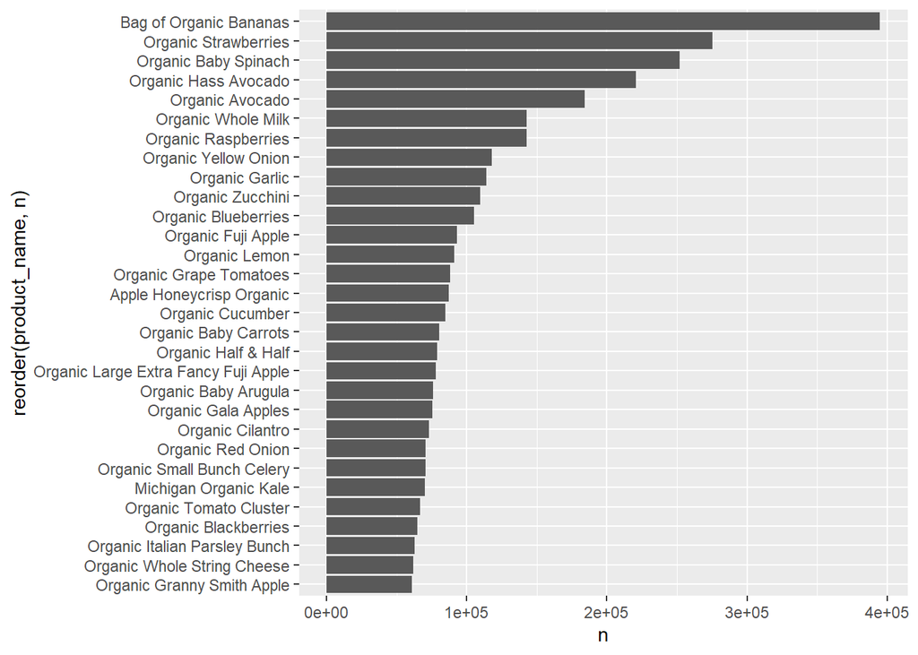

```r
ggplot(most_bought_org) +
  geom_col(aes(x = reorder(product_name, n), y = n)) +
  coord_flip()
```

### Antwort 2.2: Es sind : Bag of Organic Bananas, Organic Strawberries, Organic Baby Spinach, Organic Hass Avocado, Organic Avocado, Organic Whole Milk

### Frage 2.3 : Was sind die meist verkauften Nicht-Bio-Produkte?

### Antwort 2.3: Es sind : Banana, Large Lemon, Strawberries, Limes, Cucumber Kirby, Seedless Red Grapes

### Frage 2.4 : Für welche der meistgekauften Nicht-Bio-Produkte gibt es ein Bio-Äquivalent.

Dafür haben wir ein Exelliste aus den top 100 der meist verkauften Produkte erstellt und nach äquivalenten Nicht-Bio-Produkten gesucht.

### Antwort 2.4: Wir haben herausgefunden, dass es sehr häuffig ähnliche Produkte. Unserer Resultate sind in userem Word-Dokument ersichtlich. Die wichtigsten Produktarte sind : Ungesüste Mandelmilch, Griechisches Yoghurt, Soda-Getränke und Peperoni.

| ################################################################################################### |
| --- |

## Annahme 3 : Wir gehen davon aus, dass das department: other ein flexibles depatment ist. In jedem Supermarkt gibt es neben fest gelegten departments auch departments die flexibel sind. Diese werden häuffig zu Promotionszwecke verwendet. wir stellen uns vor in diesem department Werbung für Bio zu machen.

### Frage 3.1 : Wie viele Produkte im department : other sind bio?

```r
ratio_org_byOther <- products %>%
  select(is_organic,department_id)%>%
  filter(department_id == 2)%>%
  group_by(is_organic) %>%
  summarise(count = n())%>%
  collect()%>%
  spread(key = is_organic, value = count) %>%
  rename(notorganic = `0`, organic = `1`) %>%
  mutate(all_products = notorganic + organic, freqProd = organic/all_products *100)

ratio_org_byOther
```

| notorganic | organic | all_products | freqProd |
| --- | --- | --- | --- |
| 511 | 37 | 548 | 6.751825 |

```r
OrgProdOther <- round(ratio_org_byOther$freqProd,3)
```

### Antwort 3.1 : Es gibt nur 6.752 % Bio-Produkte im Department: Other.

## Auswertung 3 : Wir haben aus den meist gekauften Bio-Prdukten 2 Rezepte zusammengestellt. Es gibt sehr viel Gemüse und Früchte in dieser Rangliste,darum haben wir uns für die Power-Müsli und den Salat entschieden. Diese können individuell zusammengestellt werden und decken einen grossen Anteil der meist gekauften Bio-Produkte ab.

### Power-Müsli

- Bag of Organic Bananas
- Organic Strawberries
- Organic Whole Milk
- Organic Raspberries
- Organic Blueberries
- Organic Fuji Apple
- Apple Honeycrisp Organic
- Organic Half & Half (Milch und cream für kaffee)
- Organic Large Extra Fancy Fuji Apple
- Organic Gala Apples
- Organic Avocado
- Organic Unsweetened Almond Milk
- Organic Navel Orange
- Organic Reduced Fat 2% Milk

### Salat

- Organic Baby Spinach
- Organic Hass Avocado
- Organic Yellow Onion
- Organic Garlic
- Organic Zucchini
- Organic Lemon
- Organic Grape Tomatoes
- Organic Cucumber
- Organic Baby Carrots
- Organic Baby Arugula
- Organic Cilantro
- Organic Small Bunch Celery
- Organic Red Onion
- Organic Tomato Cluster

| ################################################################################################### |
| --- |

## Annhame 4 : Wir gehen davon aus, das der sogenannte Last-Buy eine guter Einstigspunkt für potenziellen Bio-Kunden sein kann. Denn der Lasst-Buy ist in der Regel kein rationaler Einkauf sonder ein sehr impulsiver Einkauf.

### Frage 4.1 : Wie verhält sich der Bio-Anteil der Einkäufe für den jeweiligen letzten getätigten Einkauf?

```r
#Wie verhält sich der letzte Eikauf? t_orders_lastBuy filtert alle Produkte herraus, die sich als letztes in den Warenkrob gelegt wurden.

orders_lastBuy_organic <-orders %>%
  group_by(orders_id)%>%
  arrange(desc(add_to_cart_order)) %>%
  slice(1) %>%
  select(product_id) %>%
  inner_join(products) %>%
  filter(is_organic==1) %>%
  ungroup()%>%
  summarise(n = n())
LBorganic <- orders_lastBuy_organic$n
LBnotorganic <- tally(orders)-orders_lastBuy_organic$n

ratioLBorganic <- (LBnotorganic/LBorganic)$n

ratioLBorganic
```

```
## [1] 35.05925
```